# תרגול שישי - GLM & Logistic Regression

בתרגול הקודם ביצענו רגרסיה כדי ללמוד לחזות משתנה מטרה רציף. עתה נכליל, ונלמד על משפחה של מודלים ונשתמש באחד מהם כדי לחזות משתנה מטרה בדיד (קטגורי או פשוט בוליאני) - נבצע סיווג\קלסיפיקציה.

## GLM

נזכיר כי כאשר ביצענו רגרסיה לינארית, המודל שלנו היה

\begin{align} Y=Xβ+\epsilon \\ \epsilon∼N(0,Σ) \end{align}

כאשר **מניחים** שאפסילון הינו איבר רעש המתפלג נורמלית עם ממוצע אפס ומטריצת קו-ווראינס מסוימת סיגמא.

כך, גם y יהיה משתנה מקרי בעל התפלגות נורמאלית (רב מימדית) \begin{align} Y∼N(Xβ,Σ) \end{align}

נשים לב כי בעצם בעצם תתקיים לנו הסתברות מותנת של אותו הy בהינתן הx: \begin{align} p(Y|X) = N(\phi_\beta(X), \Sigma)\ \ Where \ \ \phi_\beta(X) = X^T\beta \end{align}

כאשר המשמעות היא **ההסתברות** לראות את התוצאה y עבור וקטור הפיצ'רים x ווקטור הפרמטרים בטא. במקרה הזה ההתפלגות היא כאמור מונחת להיות נורמאלית

אבל מה אם המידע שלנו לא מתפלג נורמאלית? האם דאטא של תוצאות הטלת מטבע מתפלג נורמאלית? של תפוצה של מגפה? של מקרי שוד בשכונה?

אם כך - נכליל ונדבר על GLM - Generalized Linear Models  
משפחה של מודלים לינאריים המותאמת לעבודה עם סוגי דאטא שונים (בעלי התפלגויות שונות)  
לכל "סוג" מודל במשפחה יהיו שלושה מרכיבים עיקריים:  
- Distribution family  
- Linear predictor  
- Link Function

## Distribution Family

אם עבור רגרסיה לינארית הנחנו שהמידע שלנו מתפלג נורמאלית , נוכל להניח שיש מקרים בהן הוא מתפלג אחרת!  
סוגי מידע שונים יתפלגו בצורה שונה - נורמאלי, פואסון, ברנולי, בינומי ועוד ועוד. לכל סוג התפלגות שונה נתאים מודל (לינארי) קצת שונה

## Linear Predictor

.החלק שמבצע את התחזית הלינארית עבור רגרסיה לינארית היה

\begin{align} \phi(x) = x^T\beta \end{align}

## Link Function

השינוי העיקרי שבעצם מאפשר לנו להכליל את המודל הלינארי שראינו עד כה עבור התפלגויות שונות.  
פונקציה זו, η , היא הפונקציה שאחראית לחבר בין הסקאלה הלינארית שקיבלנו בסעיף הקודם לבין הסקאלה של ההתפלגות הרצויה.  
במילים אחרות - η ממפה בין הlinear predictor לבין ה mean (μ) של ההתפלגות של הדאטא.

\begin{align} \eta(\mu) = \phi(x) \\ \mu = \eta^-1(\phi(x)) \end{align}

מה אם כך היה הη שלנו ברגרסיה לינארית?  
פונקציית הזהות!  
מוזמנים לקרוא על הפונקציות השונות עבור ההתפלגויות השונות https://en.wikipedia.org/wiki/Generalized_linear_model#Link_function

## Logistic Regression

עתה נכיר מודל נוסף במשפחת הGLM המשמש בעיקר לקליסיפיקציה-

**Logistic Regression**  
Distribution Family: ברנולי  
Link Function: logit/sigmoid

ניזכר כי מה שאנחנו מחפשים כל הזמן זה את הפרמטרים המתאימים ביותר לפי קריטריון שקבענו (במקרה שלנו - MLE).  
נשתמש בידע שלנו על ההתפלגות, ונפתח את הנוסחא.  
אז בואו נניח שיש לנו סדרת דגימות שאנחנו יודעים שמתפלגת בינומיאלית.

\begin{align} y_1,...,y_m \\ y_i ∼ B(p) \end{align}

נשתמש בשיטת MLE

### תזכורת - Maximum Likelihood Estimator

נזכיר כי עבור משתנה מקרי X בעל הסתברות P כלשהי ופונקציית צפיפות f התלויה בפרמטר θ פונקציית הlikelihood תוגדר להיות

\begin{align} L(\theta|x):=f_\theta(x) \ \ Where \ \ \theta \in \Theta, \Theta=\{\mu, \sigma^2\} \end{align}

במילים אחרות, הפונקצייה משערכת לי "מה הסיכוי" שבהינתן x אני אקבל סט פרמטרים מסוים.  
כך, הגדרנו גם את המשערך Maximum Likelihood Estimator (MLE) עבור θ:  
בהינתן L פונקציית likelihood של איזושהו התפלגות P המוגדרת על פי θ כלשהי וX מתוך ההתפלגות הזו - נגדיר:

\begin{align} \theta \in \Theta, X ∼ P(\theta) \\ \hat{\theta}^{\mathrm{MLE}}:=argmax_{\theta \in \Theta} L(\theta|X) \end{align}

**Example** - Let's derive the mean ($\mu$) of a univariate Gaussian distribution with known standard deviation ($\sigma$).

The probability density function of a Gaussian distribution is:

\begin{align} [ f(x|\mu,\sigma) = \frac{1}{\sigma\sqrt{2\pi}} e^{-\frac{(x-\mu)^2}{2\sigma^2}} ] \end{align}

For a sample of n independent observations, the likelihood function is:

\begin{align} [ L(\mu|x_1,...,x_n) = \prod_{i=1}^n \frac{1}{\sigma\sqrt{2\pi}} e^{-\frac{(x_i-\mu)^2}{2\sigma^2}} ] \end{align}

Taking the natural logarithm (log-likelihood **):

\begin{align} [ \ell(\mu) = \ln L = -\frac{n}{2}\ln(2\pi) - n\ln(\sigma) - \sum_{i=1}^n \frac{(x_i-\mu)^2}{2\sigma^2} ] \end{align}

To find the maximum likelihood estimate, we take the derivative with respect to $\mu$ and set it equal to zero:

\begin{align} [ \frac{\partial \ell}{\partial \mu} = \sum_{i=1}^n \frac{(x_i-\mu)}{\sigma^2} = 0 ] \end{align}

Solving for $\mu$:

\begin{align} [ \sum_{i=1}^n (x_i-\mu) = 0 ] \end{align}

\begin{align} [ \sum_{i=1}^n x_i - n\mu = 0 ] \end{align}

\begin{align} [ \mu = \frac{1}{n}\sum_{i=1}^n x_i ] \end{align}

Therefore, the maximum likelihood estimate for the mean of a Gaussian distribution is the sample mean: \begin{align} [ \hat{\mu}_{MLE} = \bar{x} = \frac{1}{n}\sum_{i=1}^n x_i ] \end{align}

** Since the logarithm function is a monotonous increasing transformation, the maximizer of the likelihood function is also the maximizer of the log-likelihood.

נחזור עכשיו לבעיה שלנו, וננסה לשערך את θ באמצעות MLE עבור הגדרת הבעיה שהייתה לנו (ברנולי)

\begin{align} L(\theta|y_1,...y_m)=\Pi{p^{y_i}(1-p)^{1-y_i}} \\ apply \ log \ on \ L(\theta|y_1,...y_m) \\ log-likelihood = \Sigma{y_ilog(p)+(1-y_i)log(1-p)} \end{align}

נותר אם כך רק להציב את הlink function ולפתור

כפי שציינו למעלה, בlogistic regression אנו משתמשים בפונקציית הlogit ופונקציית הסיגמואיד ההופכית לה (שגם ראינו בתרגול הקודם)

\begin{align} logit: \ log(\frac{p}{1-p})=\eta=\sigma^{-1}(\eta) \, \ (0,1) \rightarrow (-\infty,+\infty) \\ sigmoid: \ \sigma=\frac{e^\eta}{1+e^\eta} = \frac{1}{1+e^{-\eta}} \, \ (-\infty,+\infty) \rightarrow (0,1) \end{align}

ובסימונים שהראנו מקודם:

\begin{align} \eta=logit: \ logit(p) = \phi(x)=X\beta \\ p = \eta^-1(\phi(x)) = \sigma(\phi(x)) \end{align}

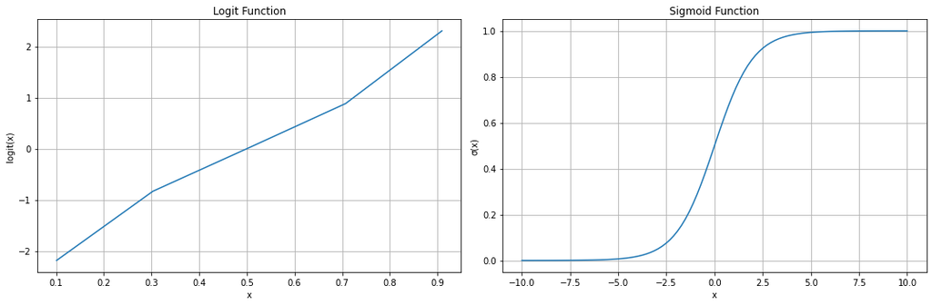

```python
import numpy as np
import matplotlib.pyplot as plt

x = np.linspace(-10, 10, 100)
# define and plot the logit and the sigmoid functions
# Define logit function
logit = np.log(x/(1-x))

# Define sigmoid function
sigmoid = 1 / (1 + np.exp(-x))

# Create figure with two subplots
plt.figure(figsize=(15,5))

# Plot logit function
plt.subplot(1,2,1)
plt.plot(x[1:-1], logit[1:-1]) # Exclude endpoints due to division by 0
plt.grid(True)
plt.title('Logit Function')
plt.xlabel('x')
plt.ylabel('logit(x)')

# Plot sigmoid function
plt.subplot(1,2,2)
plt.plot(x, sigmoid)
plt.grid(True)
plt.title('Sigmoid Function')
plt.xlabel('x')
plt.ylabel('σ(x)')

plt.tight_layout()
plt.show()
```

recap קצר - אנחנו מחפשים את סט הפרמטרים (שהוא במקרה שלנו beta) המתאימים ביותר לייצר את הy (בעצם p) הללו בהינתן הxים שקיבלנו.  
נעדכן את ההנחות שלנו עם שימוש בlink function -  
אנו מניחים כי

\begin{align} y_i ∼ B(\eta(\phi(x))) = B(\sigma(x_i^T\beta)) \end{align}

ובשביל למצוא את הפרמטרים נציב חזרה בMLE (וניזכר שאנחנו בבעיה בינארית), נגזור ונשווה ל0

\begin{align} log-likelihood = \Sigma{y_ilog(p)+(1-y_i)log(1-p)} =\\ \Sigma{y_ilog(\frac{e^{x_i^T\beta}}{1+e^{x_i^T\beta}})+(1-y_i)log(1-\frac{e^{x_i^T\beta}}{1+e^{x_i^T\beta}})} =\\ \Sigma^m_{i=1}{y_i*x_i^T\beta-log(1+e^{x_i^T\beta})} \end{align}

אך איזה באסה - אין פתרון סגור לבעיה הזאת מה נוכל לעשות?

## Gradient Descent

אלגוריתם אופטימיזציה איטרטיבי - יותר בהרצאה  
האלגוריתם בכלליות:

For a function F(θ) we want to minimize:  
(1) Pick a value for θ  
(2) While (|F'(θ)| > small value)  
θ = θ - ηF'(θ)  
(Where η is the learning rate)

## Prediction

אוקיי אז נניח שמצאנו את בטא ומזה קיבלנו את פונקציית הסיגמואיד הספציפית (שבה הyים הם הסתברות) - אבל מה עכשיו?  
כפי שציינו, אנחנו נמצאים בעולם של קליספיקציה - רוצים לחלק את הדגימה למחלקה מסוימת.  
איך נעשה זאת? קביעת סף! (מישור מפריד)  
נבחר סף α כלשהו בין 0ל1, כאשר כל מה שמתחתיו יהיה מחלקה מסוימת, וכל מה שמעליו יהיה מחלקה אחרת.

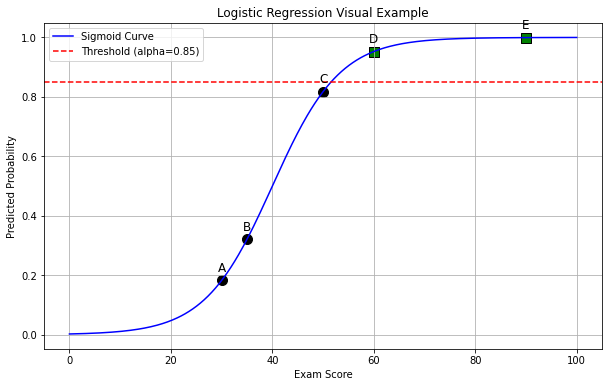

```python
import numpy as np
import matplotlib.pyplot as plt

def sigmoid(z):
    """Compute the sigmoid function."""
    return 1 / (1 + np.exp(-z))

theta0 = -6         # intercept
theta1 = 0.15       # coefficient
alpha = 0.85         # decision threshold #TODO: look how the data points shape changes as you change alpha!

exam_scores = np.array([30, 35, 50, 60, 90])
students = ["A", "B", "C", "D", "E"]

# Compute linear combination and probabilities for the synthetic data
z = theta0 + theta1 * exam_scores
probabilities = sigmoid(z)
predicted_classes = (probabilities >= alpha).astype(int)

# Generate values for a smooth sigmoid curve over a range of exam scores
x_values = np.linspace(0, 100, 400)
z_values = theta0 + theta1 * x_values
y_values = sigmoid(z_values)

plt.figure(figsize=(10, 6))

# Plot the sigmoid curve
plt.plot(x_values, y_values, label='Sigmoid Curve', color='blue')

plt.axhline(y=alpha, color='red', linestyle='dashed', label=f'Threshold (alpha={alpha})')

for i, score in enumerate(exam_scores):
    if predicted_classes[i] == 1:
        marker = 's'   # square for class 1
        color = 'green'
    else:
        marker = 'o'   # circle for class 0
        color = 'black'
    plt.scatter(score, probabilities[i], marker=marker, color=color, s=100, edgecolors='k')
    plt.text(score, probabilities[i] + 0.03, f'{students[i]}', ha='center', fontsize=12)

plt.xlabel('Exam Score')
plt.ylabel('Predicted Probability')
plt.title('Logistic Regression Visual Example')
plt.legend()
plt.grid(True)
plt.show()
```

## שאלה 1

בשנת 2008 פרסם הNIH האמריקאי מידע על אודות 4238 תושבי העיר פארמינגהם במדינת מסצ'וסטס.  
המידע כלל נתונים על בריאותם של המשתתפים במחקר והאם בתוך עשור המשתתפים זוהו כסובלים ממחלות בכלי הדם הכליליים בלב. המידע זמין בקובץ 6_heart_disease_2.csv.

הערה: הדאטאסט אמיתי וניתן להורדה בצורה חופשית. הנתונים בו שונו לצורך הדוגמה.

א. טענו את הקובץ לאובייקט מסוג DataFrame.

```python
%pip install numpy pandas matplotlib seaborn scikit-learn statsmodels
```

```python
import pandas as pd

df = pd.read_csv('6_heart_disease_2.csv')
df.sample(5)
```

|  | male | age | education | currentSmoker | cigsPerDay | BPMeds | prevalentStroke | prevalentHyp | diabetes | totChol | sysBP | diaBP | BMI | heartRate | glucose | TenYearCHD |
| --- | --- | --- | --- | --- | --- | --- | --- | --- | --- | --- | --- | --- | --- | --- | --- | --- |
| 2590 | 0 | 44 | 2.0 | 1 | 20.0 | 0.0 | 0 | 0 | 0 | 295.0 | 114.0 | 85.0 | 23.10 | 85.0 | 84.0 | 0 |
| 1822 | 1 | 48 | 1.0 | 1 | 35.0 | 0.0 | 0 | 0 | 0 | 188.0 | 120.0 | 82.5 | 31.67 | 80.0 | 68.0 | 0 |
| 3013 | 1 | 42 | 4.0 | 0 | 0.0 | 0.0 | 0 | 0 | 0 | 191.0 | 118.0 | 80.0 | 24.98 | 62.0 | 63.0 | 0 |
| 2225 | 1 | 38 | 4.0 | 0 | 0.0 | 0.0 | 0 | 0 | 0 | 240.0 | 122.5 | 80.0 | 23.97 | 60.0 | 43.0 | 0 |
| 3567 | 1 | 37 | 2.0 | 0 | 0.0 | 0.0 | 0 | 0 | 0 | 212.0 | 114.5 | 77.0 | 31.22 | 87.0 | 68.0 | 0 |

```python
df.describe().T
```

|  | count | mean | std | min | 25% | 50% | 75% | max |
| --- | --- | --- | --- | --- | --- | --- | --- | --- |
| male | 4238.0 | 0.429212 | 0.495022 | 0.00 | 0.00 | 0.0 | 1.000 | 1.0 |
| age | 4238.0 | 49.584946 | 8.572160 | 32.00 | 42.00 | 49.0 | 56.000 | 70.0 |
| education | 4133.0 | 1.978950 | 1.019791 | 1.00 | 1.00 | 2.0 | 3.000 | 4.0 |
| currentSmoker | 4238.0 | 0.494101 | 0.500024 | 0.00 | 0.00 | 0.0 | 1.000 | 1.0 |
| cigsPerDay | 4209.0 | 9.003089 | 11.920094 | 0.00 | 0.00 | 0.0 | 20.000 | 70.0 |
| BPMeds | 4185.0 | 0.029630 | 0.169584 | 0.00 | 0.00 | 0.0 | 0.000 | 1.0 |
| prevalentStroke | 4238.0 | 0.005899 | 0.076587 | 0.00 | 0.00 | 0.0 | 0.000 | 1.0 |
| prevalentHyp | 4238.0 | 0.310524 | 0.462763 | 0.00 | 0.00 | 0.0 | 1.000 | 1.0 |
| diabetes | 4238.0 | 0.025720 | 0.158316 | 0.00 | 0.00 | 0.0 | 0.000 | 1.0 |
| totChol | 4188.0 | 236.721585 | 44.590334 | 107.00 | 206.00 | 234.0 | 263.000 | 696.0 |
| sysBP | 4238.0 | 138.430746 | 28.790759 | 83.50 | 118.00 | 131.0 | 153.000 | 335.0 |
| diaBP | 4238.0 | 82.893464 | 11.910850 | 48.00 | 75.00 | 82.0 | 89.875 | 142.5 |
| BMI | 4219.0 | 25.802008 | 4.080111 | 15.54 | 23.07 | 25.4 | 28.040 | 56.8 |
| heartRate | 4237.0 | 75.878924 | 12.026596 | 44.00 | 68.00 | 75.0 | 83.000 | 143.0 |
| glucose | 3850.0 | 81.966753 | 23.959998 | 40.00 | 71.00 | 78.0 | 87.000 | 394.0 |
| TenYearCHD | 4238.0 | 0.151958 | 0.359023 | 0.00 | 0.00 | 0.0 | 0.000 | 1.0 |

ב. בטבלאת הנתונים עמודה אחת לקיומה של מחלת לב - TenYearCHD ושש עמודות של משתנים רציפים.  
עבור כל זוג משתנים רציפים צרו תרשים המתאר את התפלגות הדגימות כתלות בשני המשתנים. על צבע הדגימה לשקף את סוג הדגימה - כלומר האם היא דגימה של אדם אשר לקה במחלת לב כלילית או לא.

```python
continuous = ['totChol','sysBP','diaBP','BMI','heartRate','glucose']
```

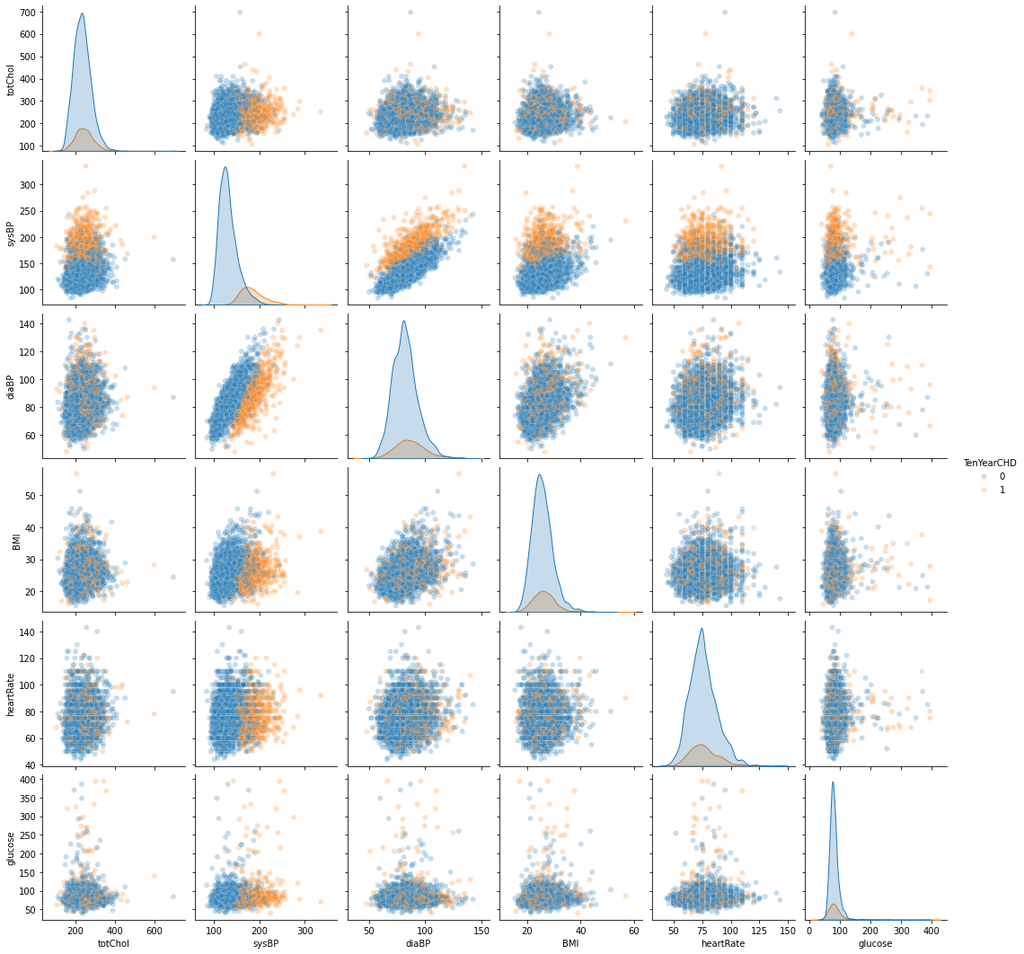

```python
import seaborn as sns

pairp = sns.pairplot(
    df[continuous + ['TenYearCHD']],
    hue='TenYearCHD',
    plot_kws={'alpha':0.25}
)
```

בתרשים למעלה אנחנו רואים את עמודות הפיצ'רים (למשל דופק בעת הגעה לרופא, אינדקס מסת גוף ועוד) אחת כתלות בשנייה. כאשר כל נקודה היא מקרה מהמדגם (שורה יצת הדאטא). הצבע הוא עמודת המטרה. בכל המשבצות שבשורה מסוימת ציר ה-Y הוא פיצ"ר מסוים, למשל בכל הגרפים בשורה שנייה ציר ה-Y הוא ה- SysBP, ולהפך בכל התמונות בעמודה השנייה, ה- SysBP ציר ה-X  
באלכסון מוצגות היסטוגרמות של הערכים בחלוקה לעמודת המטרה כאשר ציר X הוא פיצ"ר הרלוונטי למשל ה-SysBP משבצת השנייה באלכסון.  
ניתן לראות שה-SysBP (ובמידה פחותה ה-diaBP) נותנות הפרדה טובה בין הצבעים כלומר בעלות פוטנציאל לסיווג (חיזוי המטרה) ע"י השוואה לסף בחד מימד או העברת ישר חוצה בדו-מימד

----------------------------------------------------------------------------------------------

ג. צרו מודל לינארי לניבוי האם נבדק יחלה או לא יחלה על בסיס פצ'ר אחד.  
נבחר במודל מסוג רגרסיה לוגיסטית. נשים לב לא להתבלבל עם מודל מסוג רגרסיה לינארית המשמש לפרדיקציה של ערכים בתחום הרציף.  
ברגרסיה לוגיסטית חד-מימדית נשתמש בפונקציה מסוג סיגמואיד ונתאים אותה לדאטא או ליתר דיוק לצפיפות היחסית של הנקודות משתי המחלקות. הסיגמואיד מחזיר מספר בתחום [0,1]. נהוג להשתמש בערך הזה כהסתברות להיות במחלקה החיובית ואנחנו נסווג דוגמה כשייכת למחלקה החיובית אם ההסתברות הזו גדולה מ0.5. כפי שבמצב החד מימדי קבענו "מישור מפריד" חד מימדי בין המחלקות השונות (סף מספרי) כך נוכל לקבוע ישר עבור המקרה הדו מימדי, מישור מפריד עבור המקרה התלת מימדי וכן הלאה וכן הלאה..

[video not shown]

My clip: https://youtube.com/clip/UgkxLiavyVaCxyxGEYrcl_33I340xpipvfC_?si=p8oh21fokYMLdlkq

Full video: https://www.youtube.com/clip/UgkxLiavyVaCxyxGEYrcl_33I340xpipvfC_

המשוואות המתארות את המודל מפורטות למטה. עבור המקרה הפרטי בו הפרדיקציה תלויה במשתנה אחד ממורכז סביב אפס עם שיפוע רבע:

\begin{align} \hat p(y=1) = \frac{1}{1+e^{-z}}\\ \end{align}

במקרה החד מימדי הכללי בו המשתנה הבלתי תלוי הוא x:

\begin{align} z = a_0 + a_1x\\ \end{align}

שני הפרמטרים קובעים את מיקום ואת חדות המעבר מ-0 ל-1 במקרה הכללי בו הנקודה מיוצגת על ידי ווקטור של משתנים בלתי תלויים X ומקדמים A:

\begin{align} z = A^TX\\ \end{align}

השיפועים הצמודים למשתנים השונים קובעים את הוקטור של ציר ההשתנות ושל משטחי ההפרדה הניצבים לו (ובנוסף, את חדות ההפרדה שתגדל אם נכפיל את כל השיפועים באותו מספר)

נשתמש במקרה החד מימדי כדי להדגים איך הפרמטרים למעלה משפיעים על צורת הפונקציה,

נתחיל עם המאפיין sysBP - אשר מדווח על לחץ הדם הסיסטולי של המטופל בהגעה למרפאה.  
נבחר בו משום שבתרשים למעלה ניתן לראות הפרדה טובה של שתי המחלקות לפי המאפיין הזה.

```
sysBP    Axes(0.547727,0.125;0.352273x0.755)
dtype: object
```

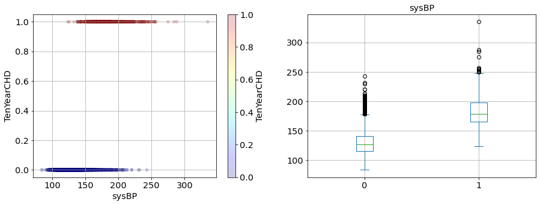

```python
import matplotlib.pyplot as plt
import numpy as np

params = {'legend.fontsize': 'x-large',
          'figure.figsize': (15, 5),
         'axes.labelsize': 'x-large',
         'axes.titlesize':'x-large',
         'xtick.labelsize':'x-large',
         'ytick.labelsize':'x-large',
         'axes.grid':True,
         'axes.grid.which':'both'
         }
plt.rcParams.update(params)

plt.subplot(1,2,1)
scatp = df[['sysBP','TenYearCHD']].plot.scatter(
    x='sysBP',
    y='TenYearCHD',
    c='TenYearCHD',
    cmap='jet',
    alpha=0.2,
    sharex=False,
    ax=plt.gca()
)
plt.subplot(1,2,2)
df[['sysBP','TenYearCHD']].plot.box(by='TenYearCHD', ax=plt.gca())
```

The boxplot is a nice summary already suggesting a threshold around sysBP=150.

Can we visualize the denisty better?

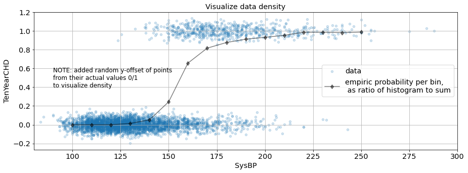

```python
plt.figure(figsize=(10, 3))

df_ = pd.DataFrame(df[['sysBP','TenYearCHD']])
df_.TenYearCHD = df_.TenYearCHD.astype('float64')
df_[['TenYearCHD']] += 0.05*np.random.randn(len(df_), 1)

scatp = df_.plot.scatter(
    x='sysBP',
    y='TenYearCHD',
    #c='TenYearCHD',
    #cmap='jet',
    sharex=False,
    colorbar=False,
    alpha=0.2,
    title='Visualize data density'
)
plt.text(90, 0.4, fontsize=12,
         s='NOTE: added random y-offset of points \nfrom their actual values 0/1 \nto visualize density',
         )

# ! Crude estimate of probability as bin-wise histograms ratio
do_density = True  # TODO True ignores unbalanced data - what's the problem with that? (prior probability..)
h1, bins = np.histogram(df_[df.TenYearCHD==1], range(90, 260, 10), density=do_density)
h0, bins = np.histogram(df_[df.TenYearCHD==0], range(90, 260, 10), density=do_density)

plt.plot(bins[1:], h1 / (h0+h1), 'kd-', alpha=0.5)
plt.legend(['data','empiric probability per bin,\n as ratio of histogram to sum'])
plt.xlim(80, 300)
plt.xlabel('SysBP')
```

כעת ננסה להתאים מודל סיגמואיד של הסתברות (רגרסיה לוגיסטית) .

```python
import statsmodels.api as sm

df.sort_values(by='sysBP', inplace=True)
x = df['sysBP']
X = sm.add_constant(x)
Y = df['TenYearCHD']

logistic_1d = sm.Logit(Y, X)
results = logistic_1d.fit()
results.summary()
```

```
Optimization terminated successfully.
         Current function value: 0.209686
         Iterations 8
```

Logit Regression Results

| Dep. Variable: | TenYearCHD | No. Observations: | 4238 |
| --- | --- | --- | --- |
| Model: | Logit | Df Residuals: | 4236 |
| Method: | MLE | Df Model: | 1 |
| Date: | Sat, 19 Apr 2025 | Pseudo R-squ.: | 0.5079 |
| Time: | 13:48:49 | Log-Likelihood: | -888.65 |
| converged: | True | LL-Null: | -1805.8 |
| Covariance Type: | nonrobust | LLR p-value: | 0.000 |

|  | coef | std err | z | P>\|z\| | [0.025 | 0.975] |
| --- | --- | --- | --- | --- | --- | --- |
| const | -14.5705 | 0.490 | -29.761 | 0.000 | -15.530 | -13.611 |
| sysBP | 0.0835 | 0.003 | 27.845 | 0.000 | 0.078 | 0.089 |

גם כאן, כמו ברגרסיה לינארית, אנחנו מקבלים מקדמים המתאימים למקדם החופשי ולמשתנה לפיו ביצענו את הרגרסיה.  
ננסה להבין את המשמעות של מה שקיבלנו. לצורך כך נשרטט את הפונקציה יחד עם הנקודות המקוריות ולצידם נשרטט את .הנקודות לפי התחזית שלהן

```
(80.0, 300.0)
```

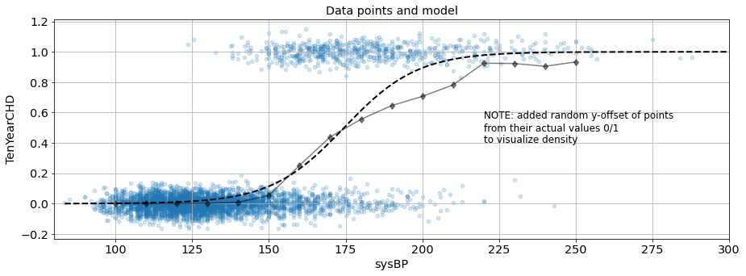

```python
plt.figure(figsize=(20, 6))
# Create a copy and add noise:
df_ = pd.DataFrame(df[['sysBP','TenYearCHD']])
df_.TenYearCHD = df_.TenYearCHD.astype('float64')
df_[['TenYearCHD']] += 0.05*np.random.randn(len(df_), 1)

scatp = df_.plot.scatter(
    x='sysBP',
    y='TenYearCHD',
    sharex=False,
    colorbar=False,
    alpha=0.2,
    title='Data points and model'
)
y_pred = results.predict(X)
logitp = plt.plot(x, y_pred, 'k--', linewidth=2)

plt.text(220, 0.4, fontsize=12,
         s='NOTE: added random y-offset of points \nfrom their actual values 0/1 \nto visualize density',
         )

h1, bins = np.histogram(df_[df.TenYearCHD==1], range(90, 260, 10))
h0, bins = np.histogram(df_[df.TenYearCHD==0], range(90, 260, 10))
plt.plot(bins[1:], h1 / (h0+h1), 'kd-', alpha=0.5)
plt.xlim(80, 300)
```

```python
# lets define a threshold and split to classes
bool_pred = results.predict(X) > 0.5
y_pred = bool_pred.astype(int)
df['logistic 1d prediction'] = y_pred
df['logistic 1d prediction']
```

```
2665    0
3578    0
420     0
2894    0
1685    0
       ..
1588    1
2091    1
864     1
3489    1
481     1
Name: logistic 1d prediction, Length: 4238, dtype: int32
```

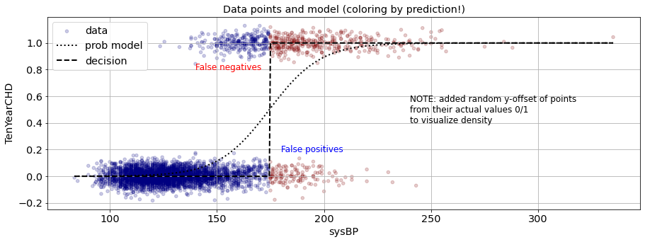

```python
# Create a copy and add noise:
df_ = pd.DataFrame(df[['sysBP','TenYearCHD', 'logistic 1d prediction']])
df_.TenYearCHD = df_.TenYearCHD.astype('float64')
df_[['TenYearCHD']] += 0.05*np.random.randn(len(df_), 1)

scatp = df_.plot.scatter(
    x='sysBP',
    y='TenYearCHD',
    c='logistic 1d prediction',
    cmap='jet',
    sharex=False,
    colorbar=False,
    alpha=0.2,
    title='Data points and model (coloring by prediction!)'
)

logitp = plt.plot(x, results.predict(X), 'k:', x, y_pred, 'k--', linewidth=2)
plt.legend(['data', 'prob model', 'decision'])

plt.text(240, 0.4, fontsize=12,
         s='NOTE: added random y-offset of points \nfrom their actual values 0/1 \nto visualize density',
         )
plt.text(180, 0.18, fontsize=12, color='b',
         s='False positives',
         )
plt.text(140, 0.8, fontsize=12, color='r',
         s='False negatives',
         )
```

## סעיף בונוס

ג. מה טיב הסיווג?

נכיר כעת את הקונספט של confusion matrix. הטבלה מתארת כמה מתוך חברי המחלקה סווגו תחת לייבל כזה או אחר של המסווג.  
אמנם ראינו טבלאות כאלה בעבר אבל ראינו אותן בהקשר של למידה לא מפוקחת, ושם אמרנו שאין משמעות לשמות המקבצים לכן אין משמעות להשמה על העמודה המתאימה. כאן יש משמעות להשמה הזו מכיוון שזו הפרדיקציה למחלקה. מכאן נובע שהמקרה האידאלי הוא קבלת מטריצה אלכסונית.

```python
CM = pd.DataFrame(
    df.groupby(['TenYearCHD','logistic 1d prediction']).size(),
    columns=['# of subjects']
)

display(CM)
CM.unstack()
```

| TenYearCHD | logistic 1d prediction | # of subjects |
| --- | --- | --- |
| 0 | 0 | 3456 |
|  | 1 | 138 |
| 1 | 0 | 274 |
|  | 1 | 370 |

| logistic 1d prediction TenYearCHD | # of subjects 0 | # of subjects 1 |
| --- | --- | --- |
| 0 | 3456 | 138 |
| 1 | 274 | 370 |

```python
from sklearn import metrics

cm = metrics.confusion_matrix(
    df['TenYearCHD'],
    df['logistic 1d prediction']
)

pd.DataFrame(cm)
```

|  | 0 | 1 |
| --- | --- | --- |
| 0 | 3456 | 138 |
| 1 | 274 | 370 |

מתוך המטריצה ניתן לגזור מדדי טיב על המודל שלנו. נכיר כעת אחד מהם - הדיוק. אופן החישוב שלו הוא סכום המספרים על האלכסון לחלק בסכום המטריצה כולה. לשמחתינו המדד הזה מיושם עבורינו.

```python
accuracy = metrics.accuracy_score(
    df['TenYearCHD'],
    df['logistic 1d prediction']
)
print(f'accuracy={accuracy*100:.1f}%')
```

```
accuracy=90.3%
```

האם המדד הזה הוא נכון ומתאים לשימוש? או שמוקדם לשמוח? כמובן שמוקדם, ניתן לראות ממטריצת השגיאות שאנחנו (באופן די קלאסי) די טובים בסיווג בריאים כבריאים, ופחות בשאר המקומות כמו שקורה כמעט תמיד, הדאטא אינו מאוזן, כמובן שבזיהוי מחלה נדירה למשל זה לא חכמה לתת תמיד תשובה שלילית ולקבל "דיוק" של 99.99% כדי לקבל תמונת מצב יותר מעמיקה צריך להסתכל על כל המטריצה ו\או על מדדים ספציפיים יותר כמו precision/recall או בשמם השני specificity/sensitivity שנפוץ יותר בקהילה הביו-רפואית נכנס לכך יותר לעומק בתרגולים הבאים

```python
classification_report = metrics.classification_report(
    df['TenYearCHD'],
    df['logistic 1d prediction']
)
print(classification_report)
```

```
              precision    recall  f1-score   support

           0       0.93      0.96      0.94      3594
           1       0.73      0.57      0.64       644

    accuracy                           0.90      4238
   macro avg       0.83      0.77      0.79      4238
weighted avg       0.90      0.90      0.90      4238
```

מצד שני, גם מטריקה לא מושלמת עשויה להיות שימושית לצורך מעקב אחר שיפורים באלגוריתם ובדיקת רעיונות

ד. צרו מודל לינארי לניבוי האם נבדק יחלה או לא על בסיס שני פיצ'רים.

תחילה נבחר פיצ'רים - על בסיס התרשים למעלה נבחר בלחץ הדם הסיסטואלי כפונקציה של לחץ הדם הדיאסטולי. נשרטט את הנקודות על המישור כדי לבחון את ההתפלגות.

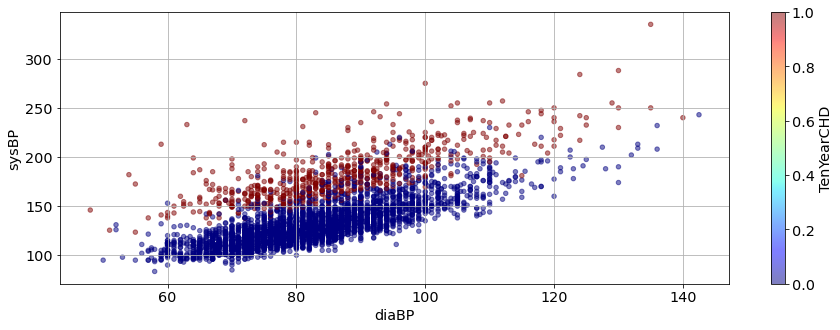

```python
scatp = df[['sysBP','diaBP','TenYearCHD']].plot.scatter(
    x='diaBP',
    y='sysBP',
    c='TenYearCHD',
    cmap='jet',
    sharex=False,
    alpha=0.5,


)
```

במודל דו-מימדי יהיו לנו שני משתנים בלתי תלויים וה"גובה" של הפונקציה (מאפס ועד אחת) יהיה משתנה בפני עצמו:

\begin{align} \hat{y} = \frac{1}{1+e^{-z}}\\ z = a_0 + a_1x + a_2y\\ \end{align}

```python
logistic_2d = sm.Logit(
    df['TenYearCHD'],
    sm.add_constant(df[['diaBP','sysBP']])
)

results_2d = logistic_2d.fit()
results_2d.summary()
```

```
Optimization terminated successfully.
         Current function value: 0.113214
         Iterations 9
```

Logit Regression Results

| Dep. Variable: | TenYearCHD | No. Observations: | 4238 |
| --- | --- | --- | --- |
| Model: | Logit | Df Residuals: | 4235 |
| Method: | MLE | Df Model: | 2 |
| Date: | Sat, 19 Apr 2025 | Pseudo R-squ.: | 0.7343 |
| Time: | 13:48:51 | Log-Likelihood: | -479.80 |
| converged: | True | LL-Null: | -1805.8 |
| Covariance Type: | nonrobust | LLR p-value: | 0.000 |

|  | coef | std err | z | P>\|z\| | [0.025 | 0.975] |
| --- | --- | --- | --- | --- | --- | --- |
| const | -9.0277 | 0.636 | -14.184 | 0.000 | -10.275 | -7.780 |
| diaBP | -0.2372 | 0.012 | -19.567 | 0.000 | -0.261 | -0.213 |
| sysBP | 0.1760 | 0.007 | 24.287 | 0.000 | 0.162 | 0.190 |

גם כעת ברצוננו לראות את הישר המפריד בין הנתונים. לצורך כך כתבתי פונקציה. אין צורך להתעכב על כל שורה בה.

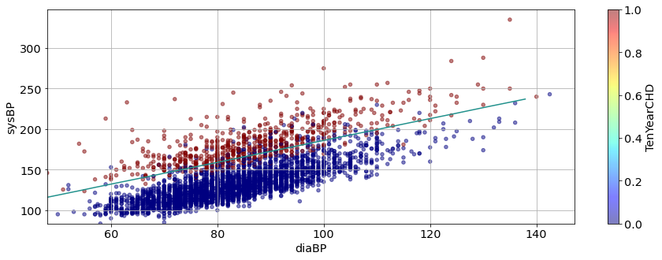

```python
import numpy as np
def decision_boundary_plot(df, x, y, results, add_c=True, p=1, level=5):
    xx, yy = np.mgrid[
        df[x].min():df[x].max():level,
        df[y].min():df[y].max():level
    ]
    grid = np.vstack([xx.ravel(), yy.ravel()]).T
    grid = pd.DataFrame(grid, columns = [x,y])**p

    if add_c:
        hh = results.predict(sm.add_constant(grid)).values.reshape(xx.shape)
    else:
        hh = results.predict(grid).values.reshape(xx.shape)

    return plt.contour(xx,yy,hh, 1)


scatp = df[['sysBP','diaBP','TenYearCHD']].plot.scatter(
    x='diaBP',
    y='sysBP',
    c='TenYearCHD',
    cmap='jet',
    sharex=False,
    alpha=0.5
)

decp = decision_boundary_plot(df, 'diaBP', 'sysBP', results_2d)
```

שימו לב, הקו המפריד יכול להפוך למישור במקרה 3-מימדי (3 פיצ"רים) או למרחב 3-מימדי משוכן בתוך מרחב 4-מימדי וכך הלאה.

הישר הניצב למישור מפריד זה הוא הישר אליו מבוצעת ההטלה, ולאורכו מתקיים המידול הסיגמואידלי

## סעיף בונוס

ה. מה טיב הסיווג?

```python
df['logistic 2d prediction'] = (
    results_2d.predict(sm.add_constant(df[['diaBP','sysBP']])) > 0.5
).astype(int)

CM = pd.DataFrame(
    df.groupby(['TenYearCHD','logistic 2d prediction']).size(),
    columns=['# of subjects']
)

CM.unstack()
```

| logistic 2d prediction TenYearCHD | # of subjects 0 | # of subjects 1 |
| --- | --- | --- |
| 0 | 3502 | 92 |
| 1 | 101 | 543 |

```python
accuracy = metrics.accuracy_score(
    df['TenYearCHD'],
    df['logistic 2d prediction']
)
print(f'2D accuracy: {accuracy*100:.1f}%')
```

```
2D accuracy: 95.4%
```

ו. השתמשו במודל רגרסיה לגיסטית על מנת לסווג לפי שני הפיצ'רים - אינדקס מסת גוף ודופק.

ראשית נשרטט את שני הפיצ'רים אחד כתלות בשני:

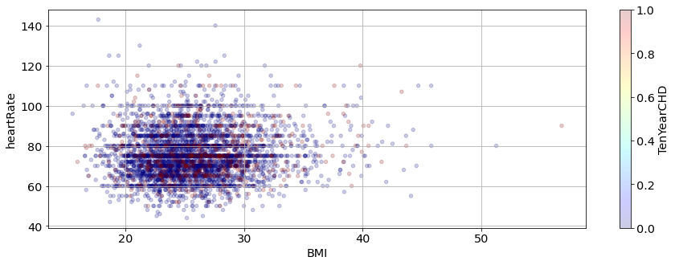

```python
scatp = df[['BMI','heartRate','TenYearCHD']].plot.scatter(
    x='BMI',
    y='heartRate',
    c='TenYearCHD',
    cmap='jet',
    sharex=False,
    alpha=0.2
)
```

נשים לב להתפלגות הנתונים. קיבלנו התפלגות מעין רדיאלית סביב מרכז כלשהו.  
לא ניתן להבחין בהבדל במרחק של כל מחלקה מהמרכז, ולמרות זאת משום שביקשו ננסה לסווג לפי הרדיוס מהמרחק:

\begin{align} \hat{y} = \frac{1}{1+e^{-z}}\\ z = a_1x^2 + a_2y^2\\ \end{align}

על מנת שלא להוסיף פרמטרים ללמידה כמו מיקום מרכז האליפסה במרחב, ננרמל את הנקודות שלנו תחילה:

```python
df_normalized = df[['BMI','heartRate']]
df_normalized.mean()
```

```
BMI          25.802008
heartRate    75.878924
dtype: float64
```

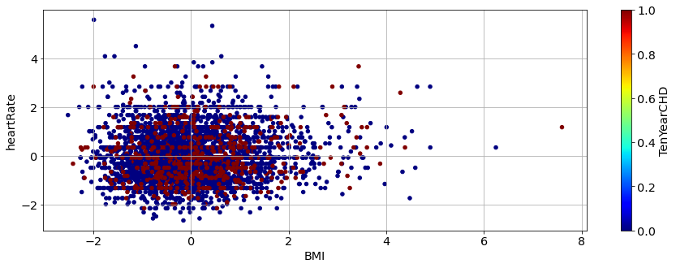

```python
df_normalized = df_normalized - df_normalized.mean()
df_normalized = df_normalized / df_normalized.std()
# COULD ALSO TRY OTHER KINDS OF NORMALIZATION...
df_normalized['TenYearCHD'] = df['TenYearCHD']

scatp_norm = df_normalized[['BMI','heartRate','TenYearCHD']].plot.scatter(
    x='BMI',
    y='heartRate',
    c='TenYearCHD',
    cmap='jet',
    sharex=False
)
```

```python
df_normalized.describe().T
```

|  | count | mean | std | min | 25% | 50% | 75% | max |
| --- | --- | --- | --- | --- | --- | --- | --- | --- |
| BMI | 4219.0 | 5.389279e-17 | 1.000000 | -2.515129 | -0.669591 | -0.098529 | 0.548513 | 7.597340 |
| heartRate | 4237.0 | 0.000000e+00 | 1.000000 | -2.650702 | -0.655125 | -0.073082 | 0.592111 | 5.581053 |
| TenYearCHD | 4238.0 | 1.519585e-01 | 0.359023 | 0.000000 | 0.000000 | 0.000000 | 0.000000 | 1.000000 |

אכן קיבלנו ממוצע אפס (שואף אליו) וסטיית תקן אחת.  
כעת נשים לב שמספר הערכים הקיימים בכל אחד מהפיצ'רים לא זהה - חשוד לקיומם של ערכים חסרים. מודלים רבים הממומשים מראש לא מיועדים להתמודד עם המצב הזה או שמיועדים לזרוק את הערכים האלה לכן זה מה שנעשה כעת.

```python
df_normalized.dropna(inplace=True)
```

לבסוף, נתאים מודל. נשים לב במשוואה שאין צורך להוסיף משתנה חופשי.

```python
logistic_2d = sm.Logit(
    df_normalized['TenYearCHD'],
    df_normalized[['BMI','heartRate']]**2
    )

results = logistic_2d.fit()
results.summary()
```

```
Optimization terminated successfully.
         Current function value: 0.574657
         Iterations 7
```

Logit Regression Results

| Dep. Variable: | TenYearCHD | No. Observations: | 4218 |
| --- | --- | --- | --- |
| Model: | Logit | Df Residuals: | 4216 |
| Method: | MLE | Df Model: | 1 |
| Date: | Sat, 19 Apr 2025 | Pseudo R-squ.: | -0.3591 |
| Time: | 13:48:52 | Log-Likelihood: | -2423.9 |
| converged: | True | LL-Null: | -1783.5 |
| Covariance Type: | nonrobust | LLR p-value: | 1.000 |

|  | coef | std err | z | P>\|z\| | [0.025 | 0.975] |
| --- | --- | --- | --- | --- | --- | --- |
| BMI | -0.3404 | 0.032 | -10.672 | 0.000 | -0.403 | -0.278 |
| heartRate | -0.6475 | 0.038 | -16.884 | 0.000 | -0.723 | -0.572 |

```python
df_normalized['logistic 2d prediction'] = (
    results.predict(df_normalized[['BMI','heartRate']]**2) > 0.45
).astype(int)
# TODO: what happens at 0.5?
```

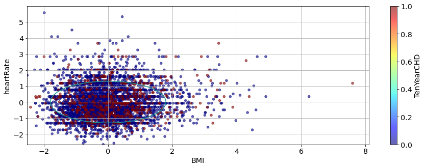

```python
df_normalized[['BMI','heartRate','TenYearCHD']].plot.scatter(
    x='BMI',
    y='heartRate',
    c='TenYearCHD',
    cmap='jet',
    sharex=False,
    alpha=0.6
)

decp = decision_boundary_plot(df_normalized, 'BMI', 'heartRate', results, add_c=False, p=2, level=0.1)
```

```python
CM = pd.DataFrame(
    df_normalized.groupby(['TenYearCHD','logistic 2d prediction']).size(),
    columns=['# of subjects']
)
display(CM)
CM.unstack()
```

| TenYearCHD | logistic 2d prediction | # of subjects |
| --- | --- | --- |
| 0 | 0 | 2744 |
|  | 1 | 841 |
| 1 | 0 | 492 |
|  | 1 | 141 |

| logistic 2d prediction TenYearCHD | # of subjects 0 | # of subjects 1 |
| --- | --- | --- |
| 0 | 2744 | 841 |
| 1 | 492 | 141 |

```python
metrics.accuracy_score(
    df_normalized['TenYearCHD'],
    df_normalized['logistic 2d prediction']
)
```

```
0.6839734471313419
```

לא ממש עבד לנו טוב וזה גם די עכבי עם הויזואליזצייה שלא הייתה מאוד מבטיחה.

ועדיין, נניח רגע שיש סיבות לחשוב שיש פוטנציאל לגישה.

איך נדע שעשינו בדיקה ממצה ואפשר לעבור לדבר הבא בסדרת ה"ניסוי וטעיה" , ולא נפלנו על באג טכני? בודקים את עצמנו על דאטא סינטטי! לפני שמקודדים סינטזה ביד, שווה לבדוק האם יש משהו מתאים באוצרות של sklearn

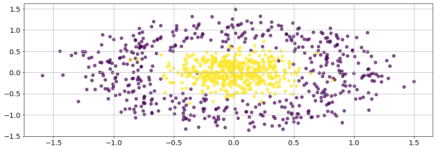

```python
from sklearn.datasets import make_circles
import matplotlib.pyplot as plt

data, labels = make_circles(n_samples=1000, noise=0.2, factor=0.2)

plt.figure()
plt.scatter(data[:,0], data[:,1], c=labels, alpha=0.7)

plt.show()
```

```python
import statsmodels.api as sm

logistic_2d_circle= sm.Logit(labels,data**2)

results = logistic_2d_circle.fit()
results.summary()
```

```
Optimization terminated successfully.
         Current function value: 0.484435
         Iterations 7
```

Logit Regression Results

| Dep. Variable: | y | No. Observations: | 1000 |
| --- | --- | --- | --- |
| Model: | Logit | Df Residuals: | 998 |
| Method: | MLE | Df Model: | 1 |
| Date: | Sat, 19 Apr 2025 | Pseudo R-squ.: | 0.3011 |
| Time: | 13:48:53 | Log-Likelihood: | -484.43 |
| converged: | True | LL-Null: | -693.15 |
| Covariance Type: | nonrobust | LLR p-value: | 8.870e-93 |

|  | coef | std err | z | P>\|z\| | [0.025 | 0.975] |
| --- | --- | --- | --- | --- | --- | --- |
| x1 | -2.4392 | 0.294 | -8.287 | 0.000 | -3.016 | -1.862 |
| x2 | -2.2812 | 0.288 | -7.911 | 0.000 | -2.846 | -1.716 |

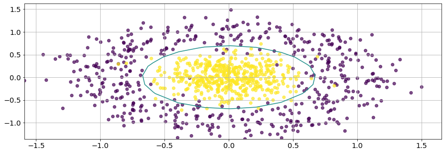

```python
df_circ=pd.DataFrame(data, columns=['x', 'y'])

decision_boundary_plot(df_circ, 'x', 'y', results, add_c=False, p=2, level=0.2)

plt.scatter(data[:,0],data[:,1] ,c=labels, alpha=0.7)
```

```python
from sklearn.metrics import confusion_matrix


pred = (results.predict(data**2) > 0.3).astype(int)
cm=pd.DataFrame(confusion_matrix(labels, pred))

cm
```

|  | 0 | 1 |
| --- | --- | --- |
| 0 | 491 | 9 |
| 1 | 19 | 481 |

```python
metrics.accuracy_score(
    labels,
    pred
)
```

```
0.972
```

נושאים לדיון המשך: א. השוו זאת למה שעשינו כדי לעשות פיט לא-ליניארי - בעזרת רגרסיה ליניארית במרחב אחר, של פיצ"רים מחושבים. ממדלים פונקציה לא-ליניארית של X , ע"יקומבינציה ליניארית של פונקציות בסיס של X

בקלסיפיקציה ע"י רגרסיה לוגיסטית על פיצ"רים מחושבים אנחנו מייצרים יריעות שוות-הסתברות צורניות. ממדלים פונקציה לוגיסטית שמשתנה לאורך ציר ישר במרחב הפיצ"רים המחושבים, . בניצב לציר זה היפר-מישורים שווי הסתברות, שמיתרגמים ליריעות עקומות במרחב הפיצ"רים המקוריים זה כולל את משטח ההפרדה p=0.5

ב. למה לעצור באליפסה? לכאורה היינו יכולים להוסיף למודל איברים מסדר ראשון (X, Y), ולקבל דרגות חופש נוספות ועוד גמישות למשטח ההפרדה - ובאופן דומה ערכים מסדר גבוה

באופן תאורטי היינו יכולים להתאים כל צורה אך יש סכנת אופברפיט.. כדי למנוע מגבילים את כמות הפיצ"רים, עוצרים מוקדם את האימון, או מוסיפים ל-LOSS אברי רגולריזצייה